# Lab_7

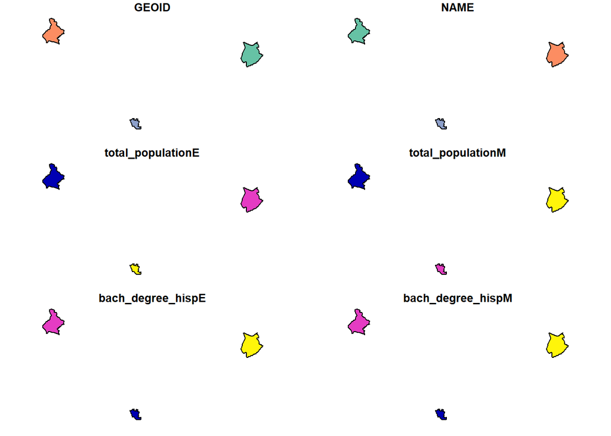

```r
#Area is equal to 56051499

plot(md_hisp_degree_2019_three_counties)
```

**7. Plot the new sf you created in question 6 using ggplot2.**

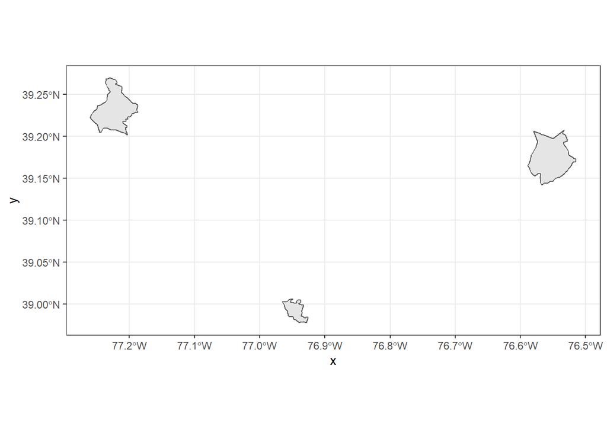

```r
#You can use this code to group census tracts in your 3 counties to produce 3 polygons, 1 for each county
md_hisp_degree_2019_three_counties %>%
  filter(GEOID == "md_hisp_degree_2019_three_counties") %>%
  ggplot() +
  geom_sf(data = md_hisp_degree_2019_three_counties) +
  geom_sf_text()
```

**8. The Environmental Protection Agency keeps a Toxics Release Inventory (TRI) of toxic chemical releases and pollution prevention activities reported by industrial and federal facilities. Download the TRI data for the state you are mapping in this assignment: https://www.epa.gov/frs/epa-frs-facilities-state-single-file-csv-download. Read your TRI .csv into R and turn it into a MULTIPOINT spatial object. (2 points)**

```r
#Filtering data from csv files
maryland_tri_2019 <- read.csv("/Users/13016/Documents/UMBC/Spring 2021/GES 486/Lab_7/state_single_md/STATE_SINGLE_MD.CSV")

#Filtering data from NA values
maryland_tri_2019_clean <-na.omit(maryland_tri_2019)

#Creating multipoint spatial object
maryland_tri_2019_multipoint <- st_as_sf(maryland_tri_2019_clean, coords = c("LONGITUDE83", "LATITUDE83"))
```

**9. Plot TRI data in only the 3 counties you selected in question 6. (3 points)** Hint: You can use `st_intersection()` to find overlap between spatial objects

```r
#Reprojecting into Web Mercator
maryland_tri_2019_multipoint_reproject <- st_set_crs(maryland_tri_2019_multipoint, 3857)

md_hisp_degree_2019_three_counties_reproject <- st_set_crs(md_hisp_degree_2019_three_counties, 3857)
#st_crs(maryland_tri_2019_multipoint_reproject)
#st_crs(md_hisp_degree_2019_three_counties_reproject)

#Using intersection to find overlap
tri_intersect <- st_intersection(md_hisp_degree_2019_three_counties_reproject, maryland_tri_2019_multipoint_reproject)
```

[figure not shown]

```r
#Plotting
ggplot(tri_intersect)+geom_sf()
```

**10. Use ggplot2 to create a choropleth map of your state for the second Census variable you selected in question 1.**

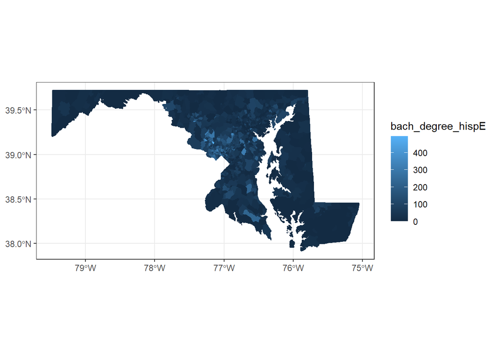

```r
md_hisp_degree_2019 %>%
  ggplot(aes(fill = bach_degree_hispE, color = bach_degree_hispE))+
  geom_sf()
```

## 3. Reflection (3 points)

When conducting data analysis, you as a researcher not only have to demonstrate your technical skills but consider your choices and their impacts. Reflecting on data analysis helps you document your process, what worked, what didn’t, and how you might improve. At the end of each class assignment you will asked to write a sort reflection.

This reflection is free-form. Use this as a space to note:

- code you want to remember about this assignment
- analysis tools you want to try with your own data
- findings that arose during your data exploration that you found interesting
- or anything else you want to take away from this CoCassignment

This lab helped me understand the importance of using st functions like st_area, st_as_if, st_intersection and other functons like read.csv. These functions helped me understad how you can create data objects and to create a chlorpleth map. These sorts of functions will help me in the future to make my own type of data objects so that I can perform other form of analysis.

## 4. Extra Credit (2 points)

**Write out one of the spatial objects you created above as a .shp file. Use QGIS or ArcGIS to open the shape file. Take a screenshot of the shape file in your GIS program window and insert the image into this Rmarkdown document.**

Knit your document to a .html file. Submit this knitted document on Canvas.